# 5261 Final Project

Yang Cai, Rui Hu, Lin Wu, Yushu Wu

GR5261: Statistical Methods in Finance

# Summary

This report presents an analysis for the recent 5 years data of 10 companies, Apple, Amazon, Bank of America, Facebook, Google, IBM, JP Morgan, Microsoft, Target and Walmart. Also, Monthly closing price from November 11, 2013 to November 11, 2018 are used to compute monthly returns of each company for the further analysis. The report contains 5 statistical analysis parts separated by the topics(pca, copula, portfolio theory, asset allocation, risk management) and a data distribution part.

# 1 Section 1. Load library and data

```r
#please go to Session-Set Working directory-To Source file location before running this code chunk
#load library
if (!require("moments")) install.packages("moments");library(moments)
if (!require("DT")) install.packages("DT");library(DT)
if (!require("dplyr")) install.packages("dplyr");library(dplyr)
if (!require("ggplot2")) install.packages("ggplot2");library(ggplot2)
if (!require("gridExtra")) install.packages("gridExtra");library(gridExtra)
if (!require("lubridate")) install.packages("lubridate");library(lubridate)
if (!require("reshape2")) install.packages("reshape2");library(reshape2)
if (!require("GGally")) install.packages("GGally");library(GGally)
if (!require("tseries")) install.packages("tseries");library(tseries)
if (!require("PerformanceAnalytics")) install.packages("PerformanceAnalytics");library(PerformanceAnalytics)
if (!require("mnormt")) install.packages("mnormt");library(mnormt)
if (!require("sn")) install.packages("sn");library(sn)
if (!require("copula")) install.packages("copula");library(copula)
source('portfolio.R')

#load stock price data
aapl = read.csv("AAPL.csv")
amzn = read.csv("AMZN.csv")
bac = read.csv("BAC.csv")
fb = read.csv("FB.csv")
goog = read.csv("GOOG.csv")
ibm = read.csv("IBM.csv")
jpm = read.csv("JPM.csv")
msft = read.csv("MSFT.csv")
tgt = read.csv("TGT.csv")
wmt = read.csv("WMT.csv")
sp500 = read.csv("SP500.csv")
riskfree = read.csv("TB4WK.csv")

#concatenate close prices
df <- cbind(aapl['Close'],amzn['Close'],bac['Close'],fb['Close'],
            goog['Close'],ibm['Close'],jpm['Close'],msft['Close'],
            tgt['Close'],wmt['Close'])
colnames(df) <- list('aapl','amzn','bac','fb','goog',
                     'ibm','jpm','msft','tgt','wmt')

#prepare a dataframe with Date and Close price
date <- aapl$Date
df_d <- data.frame(df) %>% mutate(Date=date)
df_d <- df_d[c("Date","aapl","amzn","bac","fb","goog","ibm","jpm","msft","tgt","wmt")]


#calculate stock returns
df <- data.matrix(df)
return <- matrix(nrow = 60,ncol = 10)
for(i in 1:10){
  return[,i] = exp(diff(log(df[,i]))) - 1
}
colnames(return) <- list('aapl','amzn','bac','fb','goog',
                     'ibm','jpm','msft','tgt','wmt')

#prepare a dataframe with Date and returns
date1<- aapl$Date[1:60]
re_d <- data.frame(return)%>%mutate(Date=date1)
re_d <- re_d[c("Date","aapl","amzn","bac","fb","goog","ibm","jpm","msft","tgt","wmt")]

#S&P 500 return
df_benchmark <- sp500['Close']
return_b <- matrix(NA,nrow=60,ncol=1)
return_b[,1] <- exp(diff(log(df_benchmark$Close))) - 1
```

# 2 Section 2. Descriptive Statistics

## 2.1 Sample statistics for returns

Here is the table of mean, standard deviation, skewness coefficients, kurtosis coefficients and beta of each asset.

```r
#report sample statistics
sample_stats <- data.frame(matrix(NA,ncol=5,nrow=10))
rownames(sample_stats) <- c("Apple","Amazon","Bank of America","Facebook","Google","IBM","JP Morgan","Microsoft","Target","Walmart")
colnames(sample_stats) <- c("Mean","Standard deviation","Skewness","Kurtosis","Beta")

for (i in 1:10){
  sample_stats[i,1] <- round(mean(return[,i]),3)
  sample_stats[i,2] <- round(sd(return[,i]),3)
  sample_stats[i,3] <- round(skewness(return[,i]),3)
  sample_stats[i,4] <- round(kurtosis(return[,i]),3)
  sample_stats[i,5] <- round(lm(return[,i]~return_b[,1])$coefficients[[2]],3)
}

datatable(sample_stats,caption = "Table 1: Sample statistics for returns",class = "cell-border stripe")
```

|  | Mean | Standard deviation | Skewness | Kurtosis | Beta |
| --- | --- | --- | --- | --- | --- |
| Apple | 0.016 | 0.071 | -0.237 | 0.249 | 1.16 |
| Amazon | 0.028 | 0.084 | 0.208 | 0.751 | 1.664 |
| Bank of America | 0.012 | 0.072 | 0.293 | 2.129 | 1.274 |
| Facebook | 0.02 | 0.065 | -0.072 | -0.337 | 0.576 |
| Google | 0.014 | 0.057 | 0.753 | 1.203 | 1.057 |
| IBM | -0.004 | 0.058 | -0.838 | 3.328 | 1.195 |
| JP Morgan | 0.013 | 0.053 | 0.035 | 0.492 | 1.096 |
| Microsoft | 0.02 | 0.059 | 0.404 | 1.485 | 1.239 |
| Target | 0.004 | 0.067 | 0.222 | 0.366 | 0.715 |
| Walmart | 0.005 | 0.054 | -0.052 | 1.06 | 0.275 |

## 2.2 Plot of monthly prices and returns

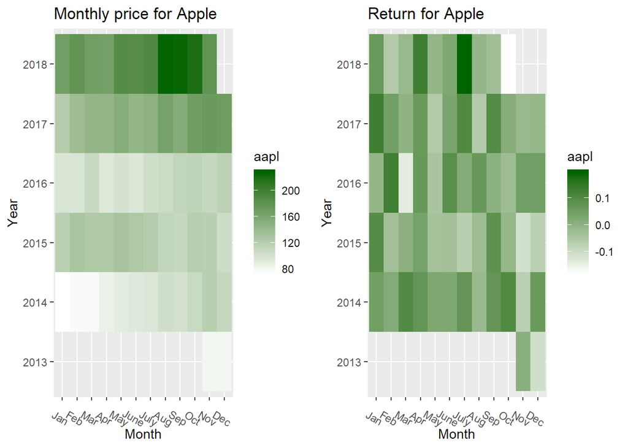

```r
#plot monthly prices & returns
#Apple monthly price
df_a <- subset(df_d,select=c("Date","aapl"))%>%mutate(month=month(Date))%>%mutate(year=year(Date))
df_a$Date <- as.Date(df_d$Date)
gg_a <- ggplot(data = df_a, aes(x = as.factor(month), y = as.factor(year))) +
  geom_tile(aes(fill=aapl))+scale_fill_gradient(low='white',high = 'dark green')+scale_x_discrete(labels=c('Jan','Feb','Mar','Apr','May','June','July','Aug','Sep','Oct','Nov','Dec'))+scale_y_discrete(labels=c(2013,2014,2015,2016,2017,2018))+ylab("Year")+xlab("Month")+labs(title="Monthly price for Apple")+theme(axis.text.x = element_text(angle=330))

#Apple return
return_a <- subset(re_d,select=c("Date","aapl"))%>%mutate(month=month(Date))%>%mutate(year=year(Date))
return_a$Date <- as.Date(re_d$Date)
gg_a_d <- ggplot(data = return_a, aes(x = as.factor(month), y = as.factor(year))) +
  geom_tile(aes(fill=aapl))+scale_fill_gradient(low='white',high = 'dark green')+scale_x_discrete(labels=c('Jan','Feb','Mar','Apr','May','June','July','Aug','Sep','Oct','Nov','Dec'))+scale_y_discrete(labels=c(2013,2014,2015,2016,2017,2018))+ylab("Year")+xlab("Month")+labs(title="Return for Apple")+theme(axis.text.x = element_text(angle=330))

grid.arrange(gg_a,gg_a_d,ncol=2)
```

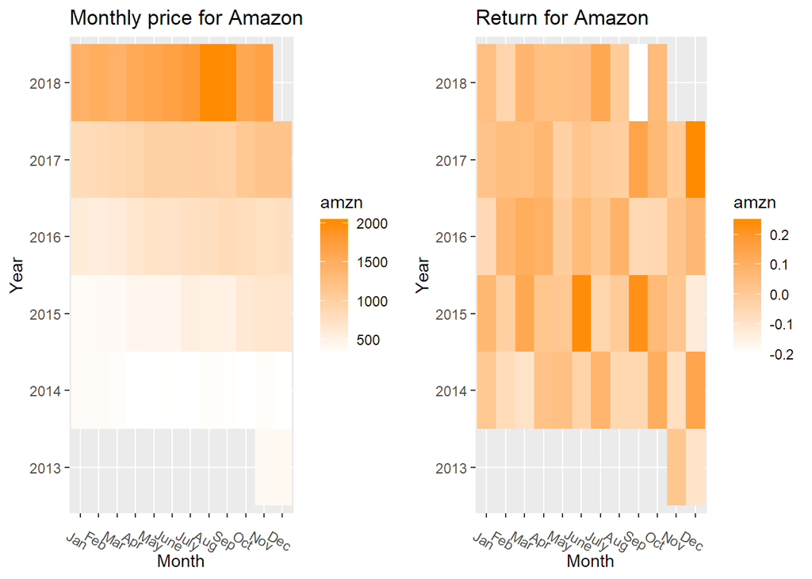

```r
#Amazon monthly price
df_az <- subset(df_d,select=c("Date","amzn"))%>%mutate(month=month(Date))%>%mutate(year=year(Date))
df_az$Date <- as.Date(df_d$Date)
gg_az <- ggplot(data = df_az, aes(x = as.factor(month), y = as.factor(year))) +
  geom_tile(aes(fill=amzn))+scale_fill_gradient(low='white',high = 'dark orange')+scale_x_discrete(labels=c('Jan','Feb','Mar','Apr','May','June','July','Aug','Sep','Oct','Nov','Dec'))+scale_y_discrete(labels=c(2013,2014,2015,2016,2017,2018))+ylab("Year")+xlab("Month")+labs(title="Monthly price for Amazon")+theme(axis.text.x = element_text(angle=330))

#Amazon return
return_az <- subset(re_d,select=c("Date","amzn"))%>%mutate(month=month(Date))%>%mutate(year=year(Date))
return_az$Date <- as.Date(re_d$Date)
gg_az_d <- ggplot(data = return_az, aes(x = as.factor(month), y = as.factor(year))) +
  geom_tile(aes(fill=amzn))+scale_fill_gradient(low='white',high = 'dark orange')+scale_x_discrete(labels=c('Jan','Feb','Mar','Apr','May','June','July','Aug','Sep','Oct','Nov','Dec'))+scale_y_discrete(labels=c(2013,2014,2015,2016,2017,2018))+ylab("Year")+xlab("Month")+labs(title="Return for Amazon")+theme(axis.text.x = element_text(angle=330))

grid.arrange(gg_az,gg_az_d,ncol=2)
```

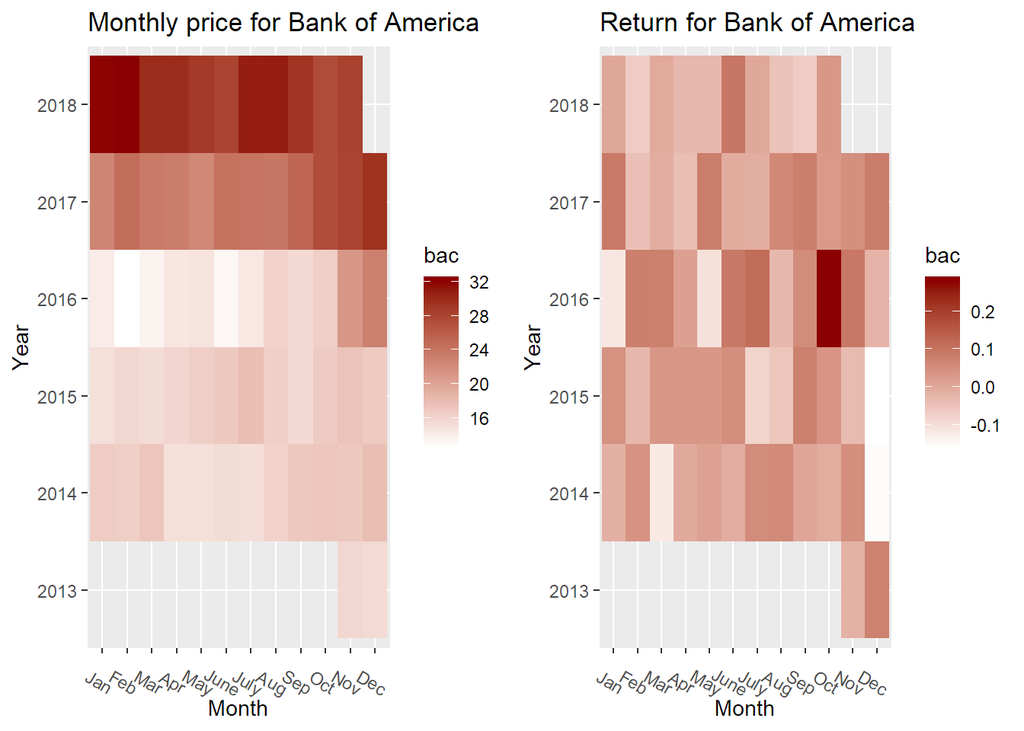

```r
#Bank of America monthly price
df_ac <- subset(df_d,select=c("Date","bac"))%>%mutate(month=month(Date))%>%mutate(year=year(Date))
df_ac$Date <- as.Date(df_d$Date)
gg_ac <- ggplot(data = df_ac, aes(x = as.factor(month), y = as.factor(year))) +
  geom_tile(aes(fill=bac))+scale_fill_gradient(low='white',high = 'dark red')+scale_x_discrete(labels=c('Jan','Feb','Mar','Apr','May','June','July','Aug','Sep','Oct','Nov','Dec'))+scale_y_discrete(labels=c(2013,2014,2015,2016,2017,2018))+ylab("Year")+xlab("Month")+labs(title="Monthly price for Bank of America")+theme(axis.text.x = element_text(angle=330))

#Bank of America return
return_ac <- subset(re_d,select=c("Date","bac"))%>%mutate(month=month(Date))%>%mutate(year=year(Date))
return_ac$Date <- as.Date(re_d$Date)
gg_ac_d <- ggplot(data = return_ac, aes(x = as.factor(month), y = as.factor(year))) +
  geom_tile(aes(fill=bac))+scale_fill_gradient(low='white',high = 'dark red')+scale_x_discrete(labels=c('Jan','Feb','Mar','Apr','May','June','July','Aug','Sep','Oct','Nov','Dec'))+scale_y_discrete(labels=c(2013,2014,2015,2016,2017,2018))+ylab("Year")+xlab("Month")+labs(title="Return for Bank of America")+theme(axis.text.x = element_text(angle=330))

grid.arrange(gg_ac,gg_ac_d,ncol=2)
```

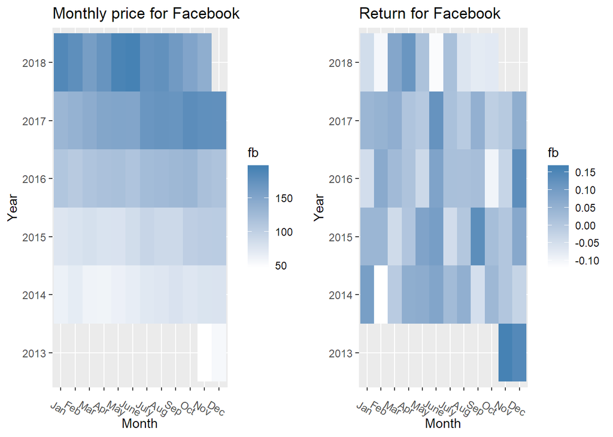

```r
#Facebook monthly prices
df_fb <- subset(df_d,select=c("Date","fb"))%>%mutate(month=month(Date))%>%mutate(year=year(Date))
df_fb$Date <- as.Date(df_d$Date)
gg_fb <- ggplot(data = df_fb, aes(x = as.factor(month), y = as.factor(year))) +
  geom_tile(aes(fill=fb))+scale_fill_gradient(low='white',high = 'steel blue')+scale_x_discrete(labels=c('Jan','Feb','Mar','Apr','May','June','July','Aug','Sep','Oct','Nov','Dec'))+scale_y_discrete(labels=c(2013,2014,2015,2016,2017,2018))+ylab("Year")+xlab("Month")+labs(title="Monthly price for Facebook")+theme(axis.text.x = element_text(angle=330))

#Facebook return
return_fb <- subset(re_d,select=c("Date","fb"))%>%mutate(month=month(Date))%>%mutate(year=year(Date))
return_fb$Date <- as.Date(re_d$Date)
gg_fb_d <- ggplot(data = return_fb, aes(x = as.factor(month), y = as.factor(year))) +
  geom_tile(aes(fill=fb))+scale_fill_gradient(low='white',high = 'steel blue')+scale_x_discrete(labels=c('Jan','Feb','Mar','Apr','May','June','July','Aug','Sep','Oct','Nov','Dec'))+scale_y_discrete(labels=c(2013,2014,2015,2016,2017,2018))+ylab("Year")+xlab("Month")+labs(title="Return for Facebook")+theme(axis.text.x = element_text(angle=330))

grid.arrange(gg_fb,gg_fb_d,ncol=2)
```

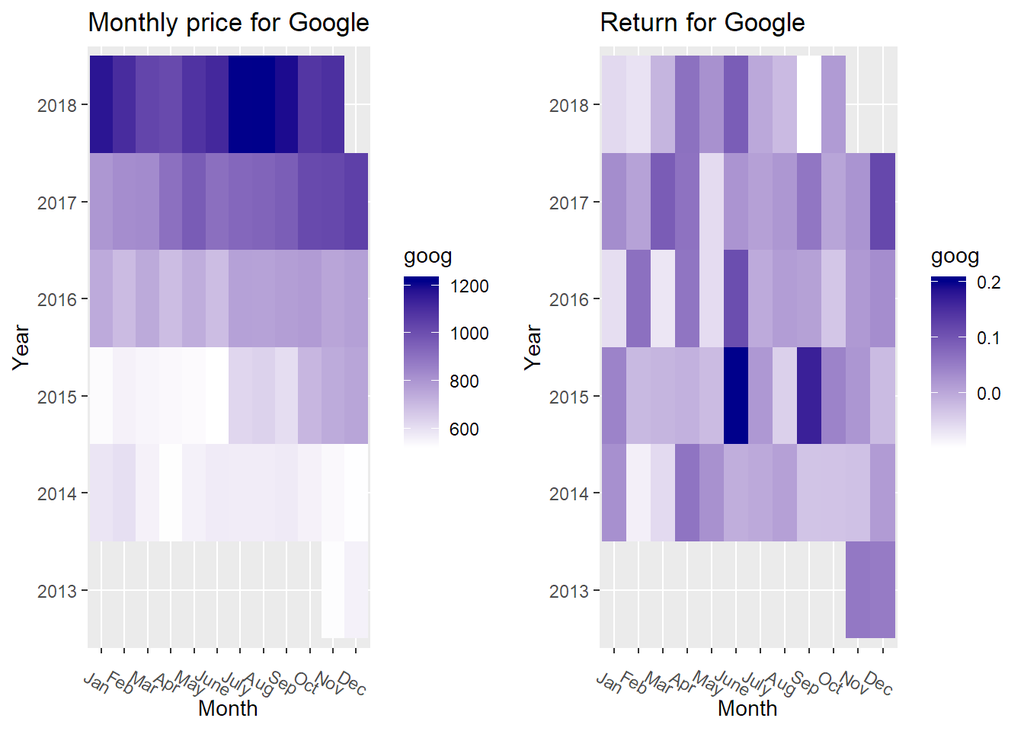

```r
#Google monthly prices
df_gg <- subset(df_d,select=c("Date","goog"))%>%mutate(month=month(Date))%>%mutate(year=year(Date))
df_gg$Date <- as.Date(df_d$Date)
gg_gg <- ggplot(data = df_gg, aes(x = as.factor(month), y = as.factor(year))) +
  geom_tile(aes(fill=goog))+scale_fill_gradient(low='white',high = 'dark blue')+scale_x_discrete(labels=c('Jan','Feb','Mar','Apr','May','June','July','Aug','Sep','Oct','Nov','Dec'))+scale_y_discrete(labels=c(2013,2014,2015,2016,2017,2018))+ylab("Year")+xlab("Month")+labs(title="Monthly price for Google")+theme(axis.text.x = element_text(angle=330))

#Google return
return_gg <- subset(re_d,select=c("Date","goog"))%>%mutate(month=month(Date))%>%mutate(year=year(Date))
return_gg$Date <- as.Date(re_d$Date)
gg_gg_d <- ggplot(data = return_gg, aes(x = as.factor(month), y = as.factor(year))) +
  geom_tile(aes(fill=goog))+scale_fill_gradient(low='white',high = 'dark blue')+scale_x_discrete(labels=c('Jan','Feb','Mar','Apr','May','June','July','Aug','Sep','Oct','Nov','Dec'))+scale_y_discrete(labels=c(2013,2014,2015,2016,2017,2018))+ylab("Year")+xlab("Month")+labs(title="Return for Google")+theme(axis.text.x = element_text(angle=330))

grid.arrange(gg_gg,gg_gg_d,ncol=2)
```

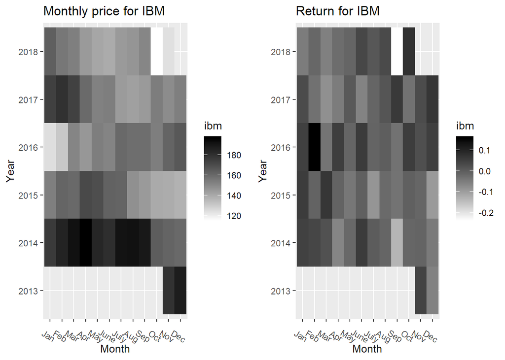

```r
#IBM monthly prices
df_ib <- subset(df_d,select=c("Date","ibm"))%>%mutate(month=month(Date))%>%mutate(year=year(Date))
df_ib$Date <- as.Date(df_d$Date)
gg_ib <- ggplot(data = df_ib, aes(x = as.factor(month), y = as.factor(year))) +
  geom_tile(aes(fill=ibm))+scale_fill_gradient(low='white',high = ' black')+scale_x_discrete(labels=c('Jan','Feb','Mar','Apr','May','June','July','Aug','Sep','Oct','Nov','Dec'))+scale_y_discrete(labels=c(2013,2014,2015,2016,2017,2018))+ylab("Year")+xlab("Month")+labs(title="Monthly price for IBM")+theme(axis.text.x = element_text(angle=330))

#IBM return
return_ib <- subset(re_d,select=c("Date","ibm"))%>%mutate(month=month(Date))%>%mutate(year=year(Date))
return_ib$Date <- as.Date(re_d$Date)
gg_ib_d <- ggplot(data = return_ib, aes(x = as.factor(month), y = as.factor(year))) +
  geom_tile(aes(fill=ibm))+scale_fill_gradient(low='white',high = 'black')+scale_x_discrete(labels=c('Jan','Feb','Mar','Apr','May','June','July','Aug','Sep','Oct','Nov','Dec'))+scale_y_discrete(labels=c(2013,2014,2015,2016,2017,2018))+ylab("Year")+xlab("Month")+labs(title="Return for IBM")+theme(axis.text.x = element_text(angle=330))

grid.arrange(gg_ib,gg_ib_d,ncol=2)
```

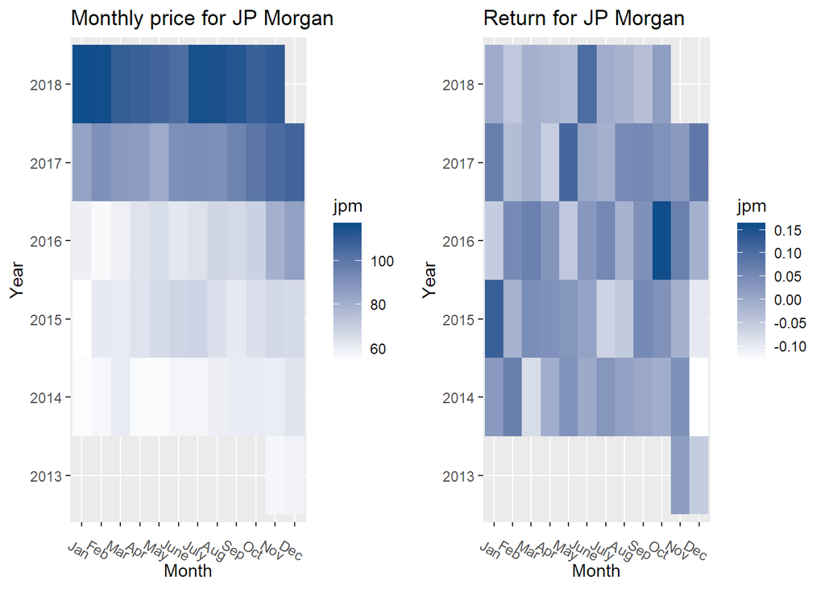

```r
#JP Morgan monthly prices
df_jp <- subset(df_d,select=c("Date","jpm"))%>%mutate(month=month(Date))%>%mutate(year=year(Date))
df_jp$Date <- as.Date(df_d$Date)
gg_jp <- ggplot(data = df_jp, aes(x = as.factor(month), y = as.factor(year))) +
  geom_tile(aes(fill=jpm))+scale_fill_gradient(low='white',high ='dodgerblue4')+scale_x_discrete(labels=c('Jan','Feb','Mar','Apr','May','June','July','Aug','Sep','Oct','Nov','Dec'))+scale_y_discrete(labels=c(2013,2014,2015,2016,2017,2018))+ylab("Year")+xlab("Month")+labs(title="Monthly price for JP Morgan")+theme(axis.text.x = element_text(angle=330))

#JP Morgan return
return_jp <- subset(re_d,select=c("Date","jpm"))%>%mutate(month=month(Date))%>%mutate(year=year(Date))
return_jp$Date <- as.Date(re_d$Date)
gg_jp_d <- ggplot(data = return_jp, aes(x = as.factor(month), y = as.factor(year))) +
  geom_tile(aes(fill=jpm))+scale_fill_gradient(low='white',high = 'dodgerblue4')+scale_x_discrete(labels=c('Jan','Feb','Mar','Apr','May','June','July','Aug','Sep','Oct','Nov','Dec'))+scale_y_discrete(labels=c(2013,2014,2015,2016,2017,2018))+ylab("Year")+xlab("Month")+labs(title="Return for JP Morgan")+theme(axis.text.x = element_text(angle=330))

grid.arrange(gg_jp,gg_jp_d,ncol=2)
```

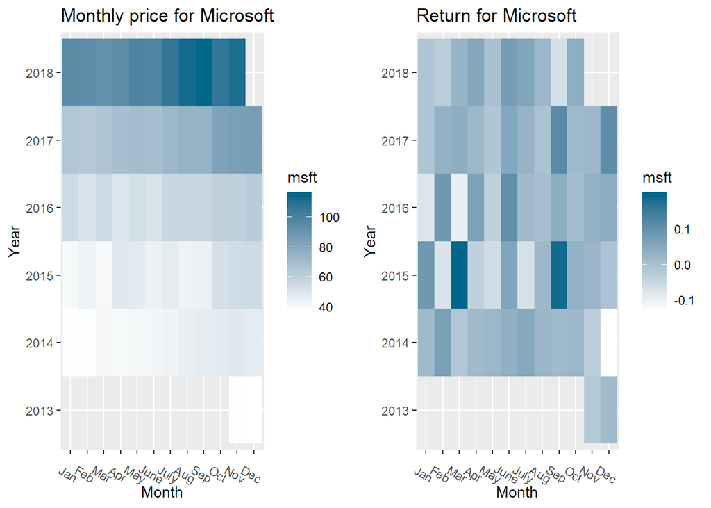

```r
#Microsoft monthly prices
df_ms <- subset(df_d,select=c("Date","msft"))%>%mutate(month=month(Date))%>%mutate(year=year(Date))
df_ms$Date <- as.Date(df_d$Date)
gg_ms <- ggplot(data = df_ms, aes(x = as.factor(month), y = as.factor(year))) +
  geom_tile(aes(fill=msft))+scale_fill_gradient(low='white',high ='deepskyblue4')+scale_x_discrete(labels=c('Jan','Feb','Mar','Apr','May','June','July','Aug','Sep','Oct','Nov','Dec'))+scale_y_discrete(labels=c(2013,2014,2015,2016,2017,2018))+ylab("Year")+xlab("Month")+labs(title="Monthly price for Microsoft")+theme(axis.text.x = element_text(angle=330))

#Microsoft return
return_ms <- subset(re_d,select=c("Date","msft"))%>%mutate(month=month(Date))%>%mutate(year=year(Date))
return_ms$Date <- as.Date(re_d$Date)
gg_ms_d <- ggplot(data = return_ms, aes(x = as.factor(month), y = as.factor(year))) +
  geom_tile(aes(fill=msft))+scale_fill_gradient(low='white',high = 'deepskyblue4')+scale_x_discrete(labels=c('Jan','Feb','Mar','Apr','May','June','July','Aug','Sep','Oct','Nov','Dec'))+scale_y_discrete(labels=c(2013,2014,2015,2016,2017,2018))+ylab("Year")+xlab("Month")+labs(title="Return for Microsoft")+theme(axis.text.x = element_text(angle=330))

grid.arrange(gg_ms,gg_ms_d,ncol=2)
```

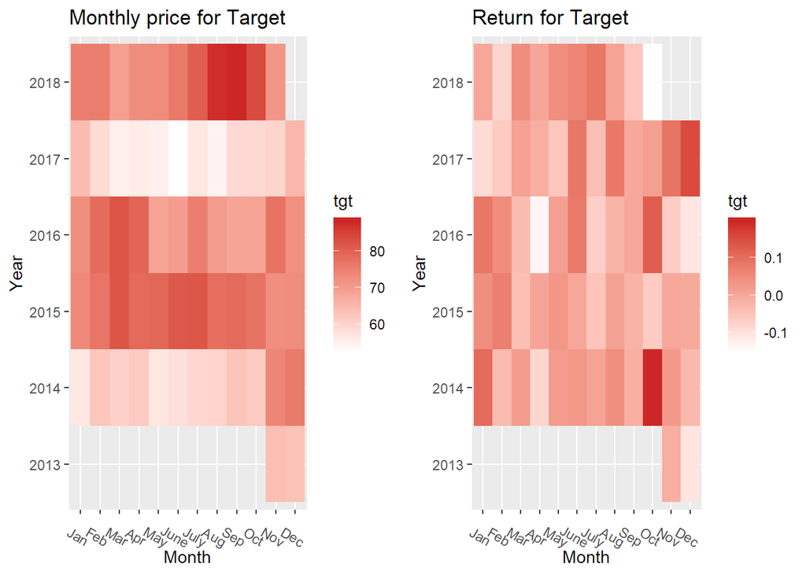

```r
#Target monthly prices
df_tg <- subset(df_d,select=c("Date","tgt"))%>%mutate(month=month(Date))%>%mutate(year=year(Date))
df_tg$Date <- as.Date(df_d$Date)
gg_tg <- ggplot(data = df_tg, aes(x = as.factor(month), y = as.factor(year))) +
  geom_tile(aes(fill=tgt))+scale_fill_gradient(low='white',high ='firebrick3')+scale_x_discrete(labels=c('Jan','Feb','Mar','Apr','May','June','July','Aug','Sep','Oct','Nov','Dec'))+scale_y_discrete(labels=c(2013,2014,2015,2016,2017,2018))+ylab("Year")+xlab("Month")+labs(title="Monthly price for Target")+theme(axis.text.x = element_text(angle=330))

#Target return
return_tg <- subset(re_d,select=c("Date","tgt"))%>%mutate(month=month(Date))%>%mutate(year=year(Date))
return_tg$Date <- as.Date(re_d$Date)
gg_tg_d <- ggplot(data = return_tg, aes(x = as.factor(month), y = as.factor(year))) +
  geom_tile(aes(fill=tgt))+scale_fill_gradient(low='white',high = 'firebrick3')+scale_x_discrete(labels=c('Jan','Feb','Mar','Apr','May','June','July','Aug','Sep','Oct','Nov','Dec'))+scale_y_discrete(labels=c(2013,2014,2015,2016,2017,2018))+ylab("Year")+xlab("Month")+labs(title="Return for Target")+theme(axis.text.x = element_text(angle=330))

grid.arrange(gg_tg,gg_tg_d,ncol=2)
```

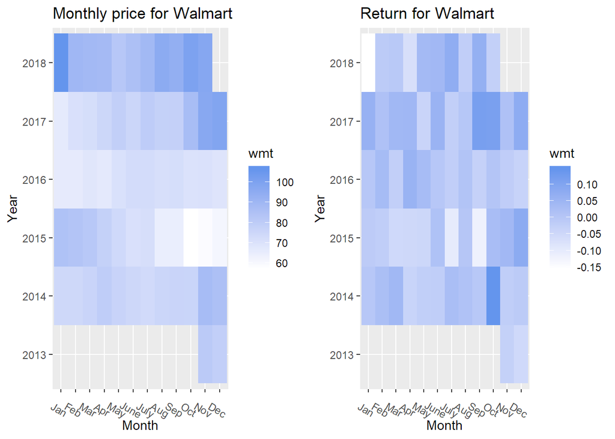

```r
#Target monthly prices
df_wmt <- subset(df_d,select=c("Date","wmt"))%>%mutate(month=month(Date))%>%mutate(year=year(Date))
df_wmt$Date <- as.Date(df_d$Date)
gg_wmt <- ggplot(data = df_wmt, aes(x = as.factor(month), y = as.factor(year))) +
  geom_tile(aes(fill=wmt))+scale_fill_gradient(low='white',high ='cornflowerblue')+scale_x_discrete(labels=c('Jan','Feb','Mar','Apr','May','June','July','Aug','Sep','Oct','Nov','Dec'))+scale_y_discrete(labels=c(2013,2014,2015,2016,2017,2018))+ylab("Year")+xlab("Month")+labs(title="Monthly price for Walmart")+theme(axis.text.x = element_text(angle=330))

#Walmart return
return_wmt <- subset(re_d,select=c("Date","wmt"))%>%mutate(month=month(Date))%>%mutate(year=year(Date))
return_wmt$Date <- as.Date(re_d$Date)
gg_wmt_d <- ggplot(data = return_wmt, aes(x = as.factor(month), y = as.factor(year))) +
  geom_tile(aes(fill=wmt))+scale_fill_gradient(low='white',high = 'cornflowerblue')+scale_x_discrete(labels=c('Jan','Feb','Mar','Apr','May','June','July','Aug','Sep','Oct','Nov','Dec'))+scale_y_discrete(labels=c(2013,2014,2015,2016,2017,2018))+ylab("Year")+xlab("Month")+labs(title="Return for Walmart")+theme(axis.text.x = element_text(angle=330))

grid.arrange(gg_wmt,gg_wmt_d,ncol=2)
```

## 2.3 Histograms

- Histograms for 10 assets

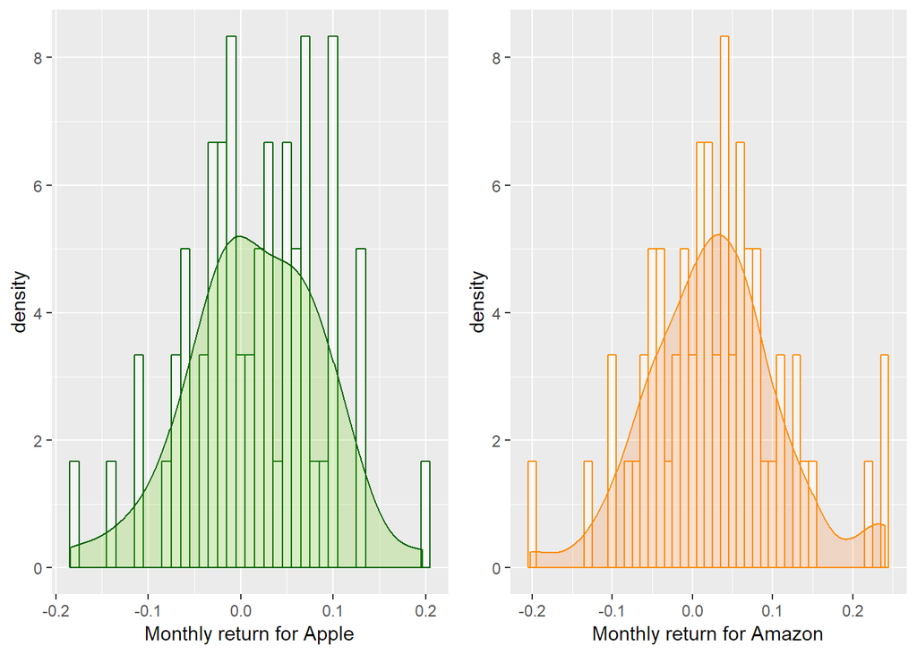

```r
#histogram for Apple
h_a <- ggplot(data=return_a,aes(x=aapl))+geom_histogram(aes(y=..density..),binwidth = 0.01,color='dark green',fill='white',alpha=0.5)+
 geom_density(alpha=.2, color='dark green',fill="chartreuse3")+xlab("Monthly return for Apple")
#histogram for Amazon
h_az <- ggplot(data=return_az,aes(x=amzn))+geom_histogram(aes(y=..density..),binwidth = 0.01,color='dark orange',fill='white',alpha=0.5)+
 geom_density(alpha=.2, color='dark orange',fill="chocolate1")+xlab("Monthly return for Amazon")
#histogram for Bank of America
h_ba <- ggplot(data=return_ac,aes(x=bac))+geom_histogram(aes(y=..density..),binwidth = 0.01,color='dark red',fill='white',alpha=0.5)+
 geom_density(alpha=.2, color='dark red',fill="darksalmon")+xlab("Monthly return for Bank of America")
#histogram for Facebook
h_fb <- ggplot(data=return_fb,aes(x=fb))+geom_histogram(aes(y=..density..),binwidth = 0.01,color='steel blue',fill='white',alpha=0.5)+
 geom_density(alpha=.2, color='steel blue',fill="lightblue1")+xlab("Monthly return for Facebook")
#histogram for Google
h_gg <- ggplot(data=return_gg,aes(x=goog))+geom_histogram(aes(y=..density..),binwidth = 0.01,color='dark blue',fill='white',alpha=0.5)+
 geom_density(alpha=.2, color='dark blue',fill="lightsteelblue1")+xlab("Monthly return for Google")
#histogram for IBM
h_ib <- ggplot(data=return_ib,aes(x=ibm))+geom_histogram(aes(y=..density..),binwidth = 0.01,color='black',fill='white',alpha=0.5)+
 geom_density(alpha=.2, color='black',fill="grey")+xlab("Monthly return for IBM")
#histogram for JP Morgan
h_jp <- ggplot(data=return_jp,aes(x=jpm))+geom_histogram(aes(y=..density..),binwidth = 0.01,color='dodgerblue4',fill='white',alpha=0.5)+
 geom_density(alpha=.2, color='dodgerblue4',fill="steelblue1")+xlab("Monthly return for JP Morgan")
#histogram for Microsoft
h_ms <- ggplot(data=return_ms,aes(x=msft))+geom_histogram(aes(y=..density..),binwidth = 0.01,color='deepskyblue4',fill='white',alpha=0.5)+
 geom_density(alpha=.2, color='deepskyblue4',fill="powderblue")+xlab("Monthly return for Microsoft")
#histogram for Target
h_tgt <- ggplot(data=return_tg,aes(x=tgt))+geom_histogram(aes(y=..density..),binwidth = 0.01,color='firebrick3',fill='white',alpha=0.5)+
 geom_density(alpha=.2, color='firebrick3',fill="indianred2")+xlab("Monthly return for Target")
#histogram for Walmart
h_wmt <- ggplot(data=return_wmt,aes(x=wmt))+geom_histogram(aes(y=..density..),binwidth = 0.01,color='cornflowerblue',fill='white',alpha=0.5)+
 geom_density(alpha=.2, color='cornflowerblue',fill="aliceblue")+xlab("Monthly return for Walmart")
grid.arrange(h_a,h_az,ncol=2)
```

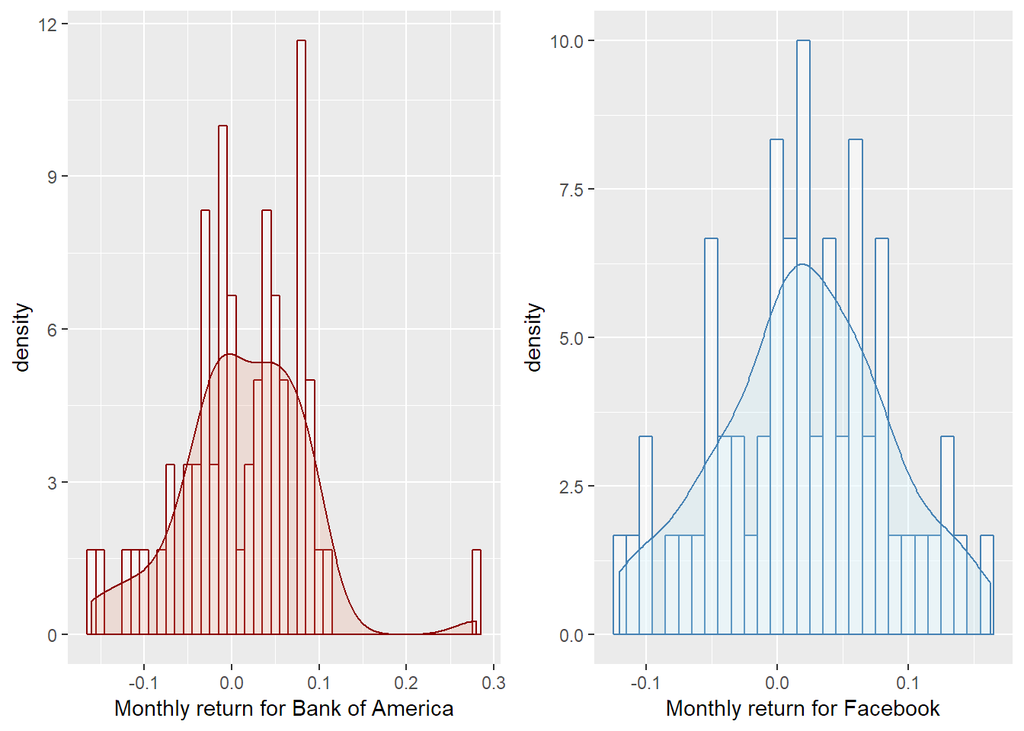

```r
grid.arrange(h_ba,h_fb,ncol=2)
```

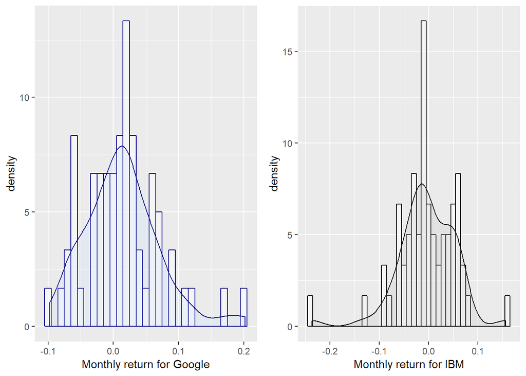

```r
grid.arrange(h_gg,h_ib,ncol=2)
```

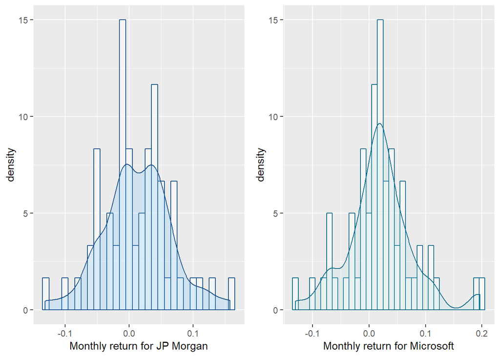

```r
grid.arrange(h_jp,h_ms,ncol=2)
```

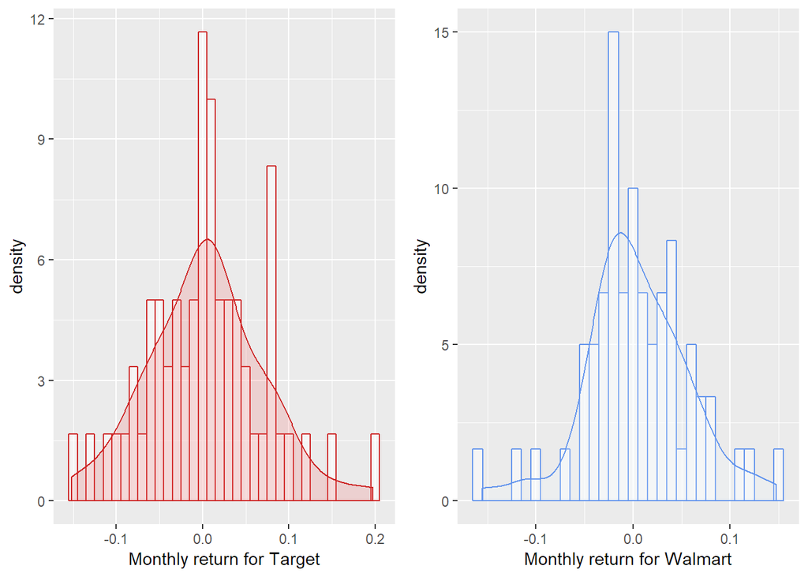

```r
grid.arrange(h_tgt,h_wmt,ncol=2)
```

## 2.4 Boxplots

- Boxplots for 10 assets

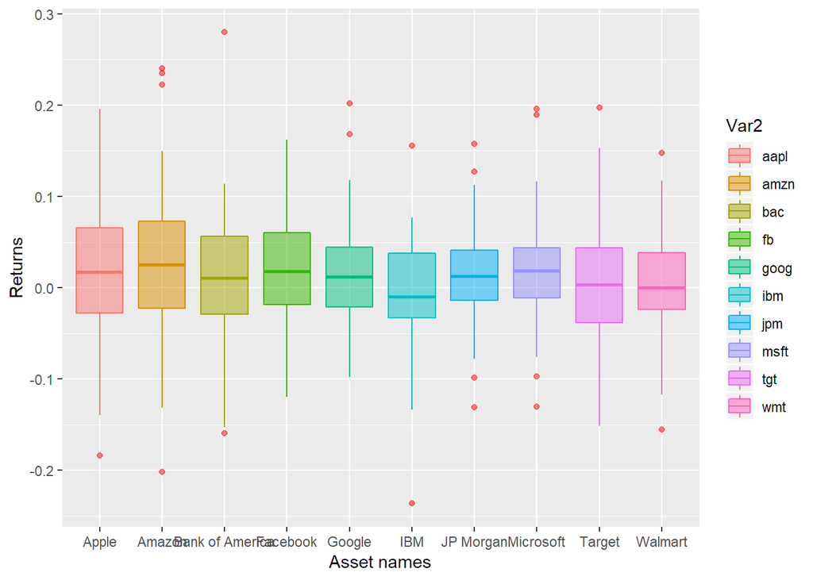

```r
m1 <- melt(return)
ggplot(data=m1,aes(x=Var2,y=value,color=Var2,fill=Var2))+geom_boxplot(alpha=0.5,outlier.color='red',outlier.shape = 19)+xlab("Asset names")+scale_x_discrete(labels=c("Apple","Amazon","Bank of America","Facebook","Google","IBM","JP Morgan","Microsoft","Target","Walmart"))+ylab("Returns")
```

## 2.5 QQ Plot

- QQplots for 10 assets

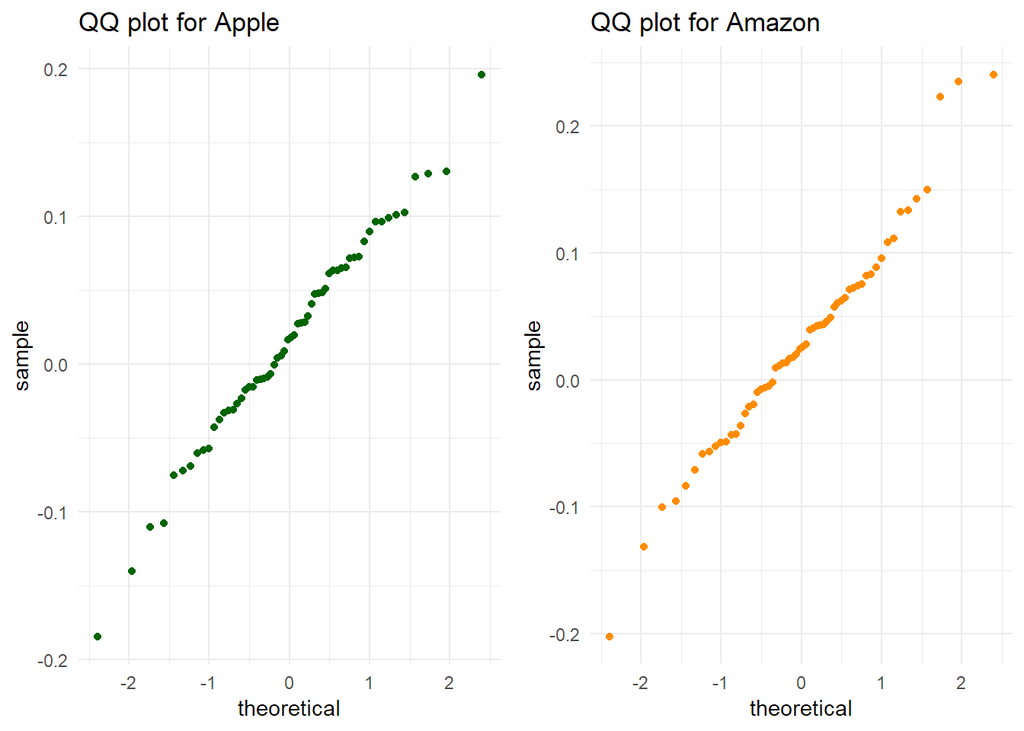

```r
#qqplot for apple
q_a <- ggplot(data.frame(return), aes(sample=aapl))+stat_qq(color='dark green')+labs(title="QQ plot for Apple")+theme_minimal()
#qqplot for amazon
q_az <- ggplot(data.frame(return), aes(sample=amzn))+stat_qq(color='dark orange')+labs(title="QQ plot for Amazon")+theme_minimal()
#qqplot for BOA
q_ac <-ggplot(data.frame(return), aes(sample=bac))+stat_qq(color='dark red')+labs(title="QQ plot for Bank of America")+theme_minimal()
#qqplot for Facebook
q_fb <- ggplot(data.frame(return), aes(sample=fb))+stat_qq(color='steel blue')+labs(title="QQ plot for Facebook")+theme_minimal()
#qqplot for Google
q_gg <- ggplot(data.frame(return), aes(sample=goog))+stat_qq(color='dark blue')+labs(title="QQ plot for Google")+theme_minimal()
#qqplot for IBM
q_ib <- ggplot(data.frame(return), aes(sample=ibm))+stat_qq()+labs(title="QQ plot for IBM")+theme_minimal()
#qqplot for JP Morgan
q_jp <- ggplot(data.frame(return), aes(sample=jpm))+stat_qq(color='dodgerblue4')+labs(title="QQ plot for JP Morgan")+theme_minimal()
#qqplot for Microsoft
q_ms <- ggplot(data.frame(return), aes(sample=msft))+stat_qq(color='deepskyblue4')+labs(title="QQ plot for Microsoft")+theme_minimal()
#qqplot for Target
q_tg <- ggplot(data.frame(return), aes(sample=tgt))+stat_qq(color='firebrick3')+labs(title="QQ plot for Target")+theme_minimal()
#qqplot for Walmart
q_wmt <- ggplot(data.frame(return), aes(sample=wmt))+stat_qq(color='cornflowerblue')+labs(title="QQ plot for Walmart")+theme_minimal()
grid.arrange(q_a,q_az,ncol=2)
```

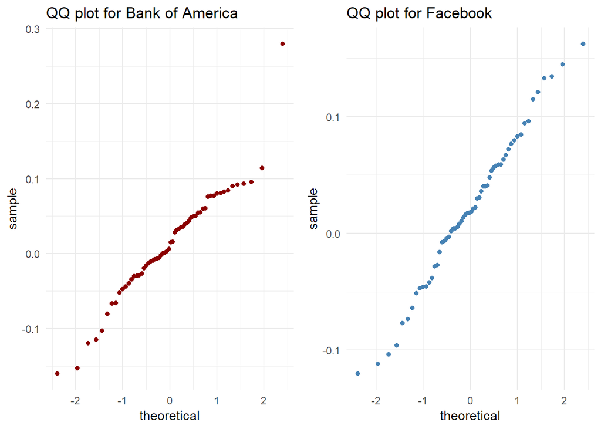

```r
grid.arrange(q_ac,q_fb,ncol=2)
```

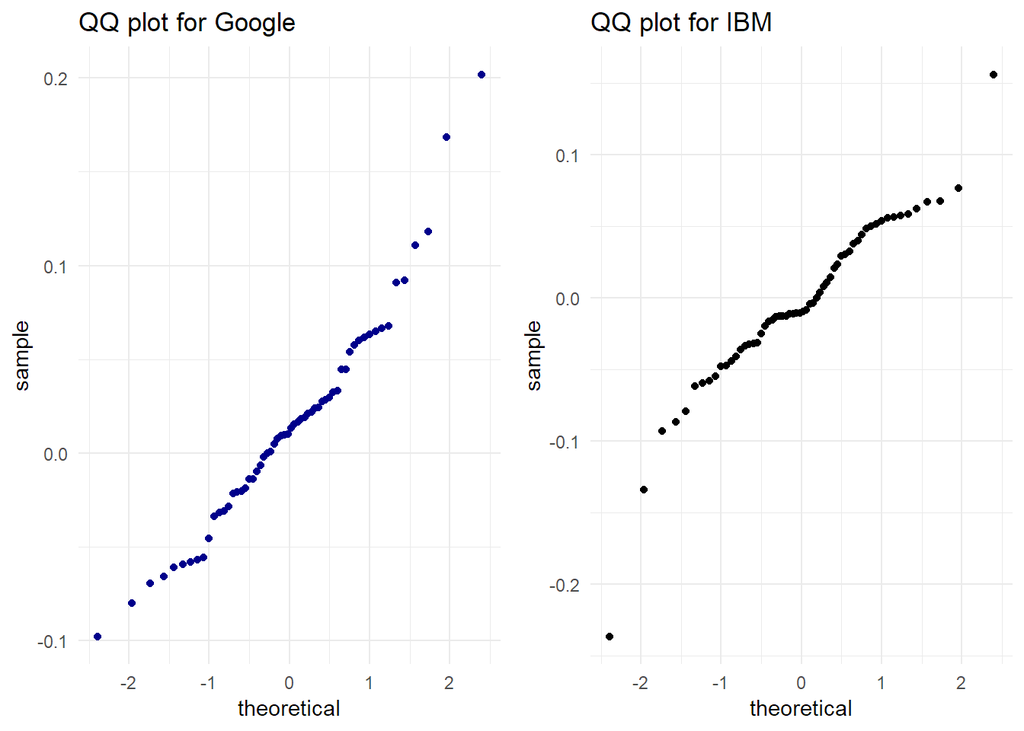

```r
grid.arrange(q_gg,q_ib,ncol=2)
```

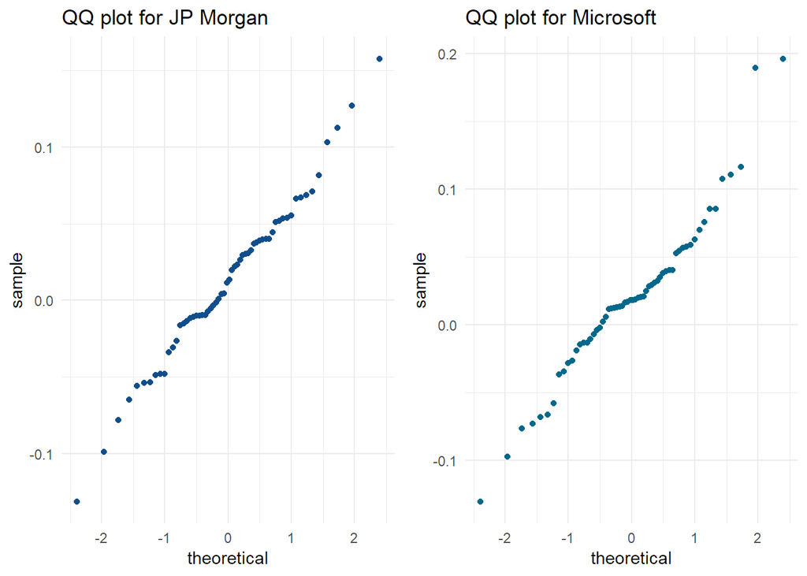

```r
grid.arrange(q_jp,q_ms,ncol=2)
```

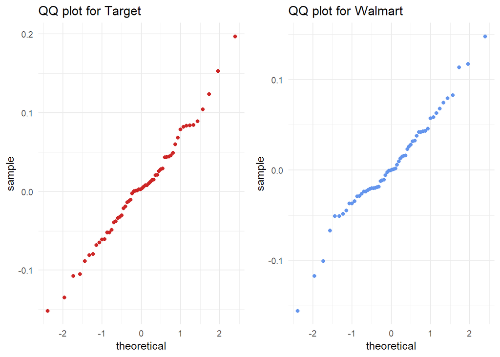

```r
grid.arrange(q_tg,q_wmt,ncol=2)
```

## 2.6 Pairwise scatter plots

Construct pairwise scatter plots for 10 assets.

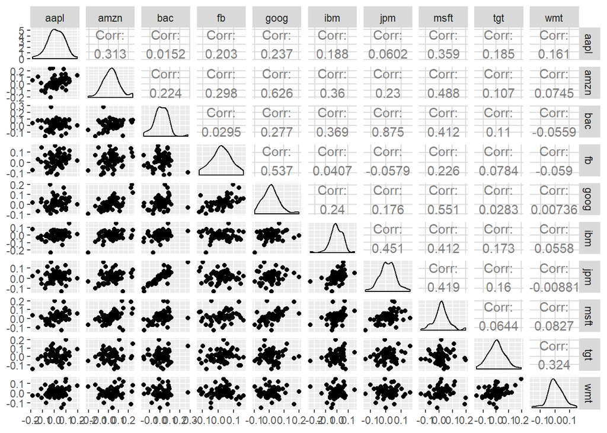

```r
ggpairs(data=data.frame(return))
```

## 2.7 Covariance matrix

```r
datatable(round(cov(return),5),caption = "Table 2: Sample covariance matrix on the returns",class="cell-border stripe")
```

|  | aapl | amzn | bac | fb | goog | ibm | jpm | msft | tgt | wmt |
| --- | --- | --- | --- | --- | --- | --- | --- | --- | --- | --- |
| aapl | 0.0051 | 0.00187 | 8e-05 | 0.00094 | 0.00097 | 0.00078 | 0.00023 | 0.00151 | 0.00089 | 0.00062 |
| amzn | 0.00187 | 0.007 | 0.00136 | 0.00162 | 0.003 | 0.00176 | 0.00103 | 0.0024 | 0.0006 | 0.00033 |
| bac | 8e-05 | 0.00136 | 0.00524 | 0.00014 | 0.00115 | 0.00156 | 0.00339 | 0.00175 | 0.00053 | -0.00022 |
| fb | 0.00094 | 0.00162 | 0.00014 | 0.00423 | 0.002 | 0.00015 | -0.0002 | 0.00086 | 0.00034 | -0.00021 |
| goog | 0.00097 | 0.003 | 0.00115 | 0.002 | 0.00329 | 0.0008 | 0.00054 | 0.00186 | 0.00011 | 2e-05 |
| ibm | 0.00078 | 0.00176 | 0.00156 | 0.00015 | 0.0008 | 0.00341 | 0.00141 | 0.00142 | 0.00068 | 0.00017 |
| jpm | 0.00023 | 0.00103 | 0.00339 | -0.0002 | 0.00054 | 0.00141 | 0.00286 | 0.00132 | 0.00058 | -3e-05 |
| msft | 0.00151 | 0.0024 | 0.00175 | 0.00086 | 0.00186 | 0.00142 | 0.00132 | 0.00346 | 0.00026 | 0.00026 |
| tgt | 0.00089 | 0.0006 | 0.00053 | 0.00034 | 0.00011 | 0.00068 | 0.00058 | 0.00026 | 0.00454 | 0.00117 |
| wmt | 0.00062 | 0.00033 | -0.00022 | -0.00021 | 2e-05 | 0.00017 | -3e-05 | 0.00026 | 0.00117 | 0.00288 |

# 3 Section 3. Principal Component Analysis

```r
#sample correlation matrix of returns
corr <- cor(df)
#msft and amzn has max correlation 0.9831232
#fb and ibm has minimum correlation -0.5771376


#pca
pca <- princomp(df,cor=T)
pca
```

```
## Call:
## princomp(x = df, cor = T)
##
## Standard deviations:
##     Comp.1     Comp.2     Comp.3     Comp.4     Comp.5     Comp.6
## 2.69317699 1.14663603 0.88879720 0.56726888 0.34853957 0.30073522
##     Comp.7     Comp.8     Comp.9    Comp.10
## 0.27999833 0.11710299 0.10344873 0.07438909
##
##  10  variables and  61 observations.
```

```r
pca$loadings
```

```
##
## Loadings:
##      Comp.1 Comp.2 Comp.3 Comp.4 Comp.5 Comp.6 Comp.7 Comp.8 Comp.9
## aapl -0.352        -0.128         0.666         0.619 -0.144
## amzn -0.362               -0.190 -0.345  0.390  0.191  0.341 -0.636
## bac  -0.348 -0.226        -0.163  0.348        -0.585 -0.181 -0.158
## fb   -0.341         0.339        -0.175 -0.800         0.233
## goog -0.360         0.186        -0.385               -0.792
## ibm   0.212 -0.569 -0.375 -0.640 -0.114 -0.133  0.217
## jpm  -0.362 -0.130        -0.157  0.184        -0.371  0.268  0.122
## msft -0.367                      -0.154  0.346  0.154  0.270  0.734
## tgt          0.735 -0.504 -0.368        -0.190 -0.130
## wmt  -0.250 -0.249 -0.660  0.592 -0.247 -0.163
##      Comp.10
## aapl
## amzn
## bac  -0.522
## fb   -0.175
## goog  0.198
## ibm
## jpm   0.754
## msft -0.289
## tgt
## wmt
##
##                Comp.1 Comp.2 Comp.3 Comp.4 Comp.5 Comp.6 Comp.7 Comp.8
## SS loadings       1.0    1.0    1.0    1.0    1.0    1.0    1.0    1.0
## Proportion Var    0.1    0.1    0.1    0.1    0.1    0.1    0.1    0.1
## Cumulative Var    0.1    0.2    0.3    0.4    0.5    0.6    0.7    0.8
##                Comp.9 Comp.10
## SS loadings       1.0     1.0
## Proportion Var    0.1     0.1
## Cumulative Var    0.9     1.0
```

```r
summary(pca)
```

```
## Importance of components:
##                           Comp.1    Comp.2     Comp.3    Comp.4     Comp.5
## Standard deviation     2.6931770 1.1466360 0.88879720 0.5672689 0.34853957
## Proportion of Variance 0.7253202 0.1314774 0.07899605 0.0321794 0.01214798
## Cumulative Proportion  0.7253202 0.8567976 0.93579370 0.9679731 0.98012108
##                             Comp.6      Comp.7      Comp.8      Comp.9
## Standard deviation     0.300735224 0.279998327 0.117102990 0.103448733
## Proportion of Variance 0.009044167 0.007839906 0.001371311 0.001070164
## Cumulative Proportion  0.989165245 0.997005151 0.998376462 0.999446626
##                             Comp.10
## Standard deviation     0.0743890921
## Proportion of Variance 0.0005533737
## Cumulative Proportion  1.0000000000
```

# 4 Section 4. Copulas

```r
#library&data
library(copula)
library(sn)
dat = return
n = 600
x1 = dat[,1]
x2 = dat[,2]
x3 = dat[,3]
x4 = dat[,4]
x5 = dat[,5]
x6 = dat[,6]
x7 = dat[,7]
x8 = dat[,8]
x9 = dat[,9]
x10 = dat[,10]

#nonparametric
edata= cbind(rank(x1)/(n + 1), rank(x2)/(n + 1), rank(x3)/(n + 1),
rank(x4)/(n + 1),rank(x5)/(n + 1),rank(x6)/(n + 1),rank(x7)/(n + 1),rank(x8)/(n + 1),rank(x9)/(n + 1),rank(x10)/(n + 1))

#correlation
corM <- cor(return,method = "spearman")
cor45 <- c(corM[1,2:10],corM[2,3:10],corM[3,4:10],corM[4,5:10],corM[5,6:10],corM[6,7:10],corM[7,8:10],corM[8,9:10],corM[9,10])

#fit copulas
fn = fitCopula(copula=normalCopula(dim = 10), data=edata,
method="ml", start=c(min(cor45)))
ft = fitCopula(copula=tCopula(dim = 10), data=edata,
method="ml", start=c(min(cor45),10))
clcop=archmCopula(family="clayton", dim=10, param=2)
fclayton = fitCopula(data=edata,method="ml", copula=clcop)
gcop=archmCopula(family="gumbel", dim=10, param=2)
fgumbel = fitCopula(data=edata,method="ml", copula=gcop)

#results
fn
```

```
## Call: fitCopula(copula, data = data, method = "ml", start = ..2)
## Fit based on "maximum likelihood" and 60 10-dimensional observations.
## Copula: normalCopula
## rho.1
## 0.889
## The maximized loglikelihood is 1097
## Optimization converged
```

```r
ft
```

```
## Call: fitCopula(copula, data = data, method = "ml", start = ..2)
## Fit based on "maximum likelihood" and 60 10-dimensional observations.
## Copula: tCopula
##   rho.1      df
##  0.8936 22.2041
## The maximized loglikelihood is 1103
## Optimization converged
```

```r
fclayton
```

```
## Call: fitCopula(copula, data = data, method = "ml")
## Fit based on "maximum likelihood" and 60 10-dimensional observations.
## Copula: claytonCopula
## alpha
## 1.138
## The maximized loglikelihood is 960.1
## Optimization converged
```

```r
fgumbel
```

```
## Call: fitCopula(copula, data = data, method = "ml")
## Fit based on "maximum likelihood" and 60 10-dimensional observations.
## Copula: gumbelCopula
## alpha
## 4.516
## The maximized loglikelihood is 1066
## Optimization converged
```

```r
AIC(fn)
```

```
## [1] -2192.34
```

```r
AIC(ft)
```

```
## [1] -2202.767
```

```r
AIC(fclayton)
```

```
## [1] -1918.196
```

```r
AIC(fgumbel)
```

```
## [1] -2130.852
```